# Simulation & Results

## Find best transmission rate

```r
lstm_predictions <- readRDS("lstm_predictions.rds")

cat(
  " LSTM CALIBRATION \n",
  "Transmission rate (ptran):", lstm_predictions[["ptran"]], "\n",
  "Contact rate (crate):     ", lstm_predictions[["crate"]], "\n",
  "R0:                       ", lstm_predictions[["R0"]], "\n"
)
```

```
 LSTM CALIBRATION
 Transmission rate (ptran): 0.0166299
 Contact rate (crate):      9.449455
 R0:                        1.100004
```

Although we got transmission rate to be 0.017, I just want to check applying various transmission rate to see which one suits best.

We start with single seed - one person infected at start, and below I am trying to find out which transmission rate. Length of period being 61 days, to match actual data and replicating 100 times, just to make it faster. So, initializing transmission rates - c(0.10, 0.15, 0.20, 0.25, 0.30), I built a 100k agent model, 4 incubation days, 1/7 recovery rate and ran it for 100 simulations, for 61 days.

Then, scaled utah cases down to 100k model scale and compared simulated vs scaled real, and picked up the rate which gave lowest RMSE value.

```r
# load pre-computed sweep results
sweep_df  <- readRDS("sweep_df.rds")
best_rate <- readRDS("best_rate.rds")

cat("Best transmission rate:", best_rate, "\n")
```

```
Best transmission rate: 0.25
```

```r
sweep_df |>
  kableExtra::kable(caption = "Parameter Sweep — Transmission Rate vs Fit") |>
  kableExtra::kable_styling(bootstrap_options = c("striped", "hover")) |>
  kableExtra::row_spec(
    which.min(sweep_df$RMSE),
    bold = TRUE, background = "#d1e7ff"
  )
```

Parameter Sweep — Transmission Rate vs Fit

| transmission_rate | MAE | RMSE | correlation |
| --- | --- | --- | --- |
| 0.10 | 0.977 | 1.049 | 0.250 |
| 0.15 | 0.917 | 0.998 | -0.065 |
| 0.20 | 0.739 | 0.880 | -0.280 |
| 0.25 | 0.697 | 0.864 | -0.266 |
| 0.30 | 1.244 | 1.662 | -0.239 |

As shown, LSTM gave much lesser transmission_rate as it was trained on SIR model with homogeneous mixing, starting point being around 30 - 50 cases. Where as, in the above model, I used the contact matrix (age-structured mixing) with single seed. So, I’ll go with transmission rate = 0.25.

Now, the model assumes the following points :

1. I only tested for the above transmission rates, so any if other transmission rate would give a better performance, isn’t tested. But since RMSE values decrease upto 0.864, then rose, best transmission rate would be around 0.25 - 0.29
2. Contact matrix is universal, which is applied to Salt Lake county as well
3. No vaccination tool added.
4. No lockdown effects.
5. Virus effected 1 person only at start, then started to spread.
6. We did not consider any other viruses like Flu
7. Person is infected until 7 days. Then recovers.
8. SEIR model assumes recovered agents are immune thereafter.

## Build Model

The entities is a list of age group and the number of agents in each age group. They are exact counts and not proportions.

```r
entities <- lapply(seq_along(dnames), function(i) {
  entity(dnames[i], entity_sizes[i], as_proportion = FALSE)
})

covid_model <- ModelSEIRMixing(
  name              = "COVID-19 Salt Lake County",
  n                 = N_agents,
  prevalence        = 1 / N_agents,
  transmission_rate = best_rate,   # data-driven
  recovery_rate     = 1 / 7,
  incubation_days   = 4,
  contact_matrix    = mm_stochastic
)
```

As shown below, the table displays proportion of age group and their population among 100k agents. census_pop is population for 1.2M. agents are its equivalent proportion among 100k population.

```r
# add age group entities
for (e in entities) add_entity(covid_model, e)

cat(
  "\n MODEL BUILD \n",
  "Total agents:", format(N_agents, big.mark = ","), "\n",
  "Number of age group entities:", length(entities), "\n",
  "\nAgent allocation per age group:\n",
  paste(
    capture.output(
      print(data.frame(
        age_group  = dnames,
        census_pop = age_tbl$population,
        fraction   = round(pop_fractions, 4),
        agents     = entity_sizes
      ))
    ),
    collapse = "\n"
  ), "\n",
  "\nModel summary:\n",
  paste(capture.output(print(covid_model)), collapse = "\n"), "\n"
)
```

```
 MODEL BUILD
 Total agents: 1e+05
 Number of age group entities: 17

Agent allocation per age group:
    age_group census_pop fraction agents
1        0-4      75800   0.0653   6533
2        5-9      79300   0.0684   6835
3      10-14      77900   0.0671   6714
4      15-19      82000   0.0707   7068
5      20-24      88500   0.0763   7628
6      25-29     102000   0.0879   8792
7      30-34     101500   0.0875   8748
8      35-39      96200   0.0829   8292
9      40-44      85500   0.0737   7369
10     45-49      74800   0.0645   6447
11     50-54      68200   0.0588   5878
12     55-59      62000   0.0534   5344
13     60-64      55000   0.0474   4741
14     65-69      43500   0.0375   3749
15     70-74      30800   0.0265   2655
16     75-79      18500   0.0159   1595
17       80+      18700   0.0161   1612

Model summary:
 ________________________________________________________________________________
Susceptible-Exposed-Infected-Removed (SEIR) with Mixing
It features 100000 agents, 1 virus(es), and 0 tool(s).
The model has 4 states. The model hasn't been run yet.
```

Below is an image of the above results.

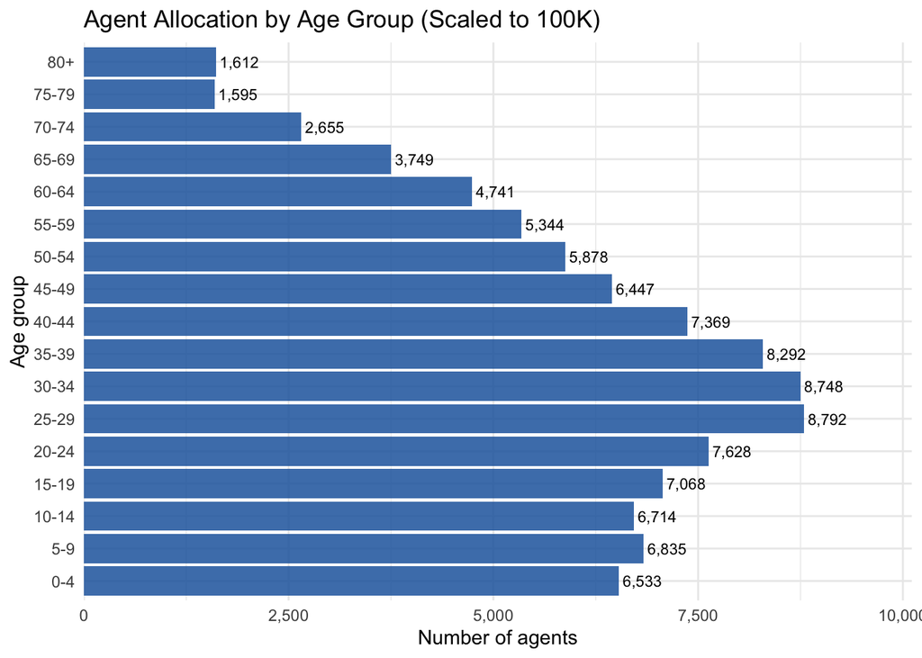

```r
p10 <- data.frame(
  age_group = dnames,
  agents    = entity_sizes
) |>
  mutate(age_group = factor(age_group, levels = dnames)) |>
  ggplot(aes(x = age_group, y = agents)) +
  geom_col(fill = "#2166ac", alpha = 0.85) +
  geom_text(aes(label = scales::comma(agents)),
            hjust = -0.1, size = 3) +
  coord_flip() +
  scale_y_continuous(labels = scales::comma,
                     expand = expansion(mult = c(0, 0.15))) +
  labs(title = "Agent Allocation by Age Group (Scaled to 100K)",
       x = "Age group", y = "Number of agents") +
  theme_minimal()
print(p10)
```

The model is run for 100 days with 500 simulations.

```r
saver <- make_saver("total_hist")

run_multiple(
  covid_model,
  ndays    = 100,
  nsims    = 500,
  saver    = saver,
  nthreads = parallel::detectCores(logical = FALSE)
)
```

```
Starting multiple runs (500)
_________________________________________________________________________
_________________________________________________________________________
||||||||||||||||||||||||||||||||||||||||||||||||||||||||||||||||||||||||| done.
```

```r
sim_results <- run_multiple_get_results(covid_model)
sim_hist    <- sim_results$total_hist

cat(
  "\n SIMULATION RUN \n",
  "Replicates completed: 500\n",
  "Days simulated: 100\n",
  "Dimensions of total_hist:", paste(dim(sim_hist), collapse = " x "), "\n",
  "Columns:", paste(names(sim_hist), collapse = ", "), "\n",
  "States recorded:", paste(unique(sim_hist$state), collapse = ", "), "\n",
  "\nFirst few rows:\n",
  paste(capture.output(print(head(sim_hist, 12))), collapse = "\n"), "\n"
)
```

```
 SIMULATION RUN
 Replicates completed: 500
 Days simulated: 100
 Dimensions of total_hist: 202000 x 5
 Columns: sim_num, date, nviruses, state, counts
 States recorded: Susceptible, Exposed, Infected, Recovered

First few rows:
    sim_num date nviruses       state counts
1        1    0        1 Susceptible  99999
2        1    0        1     Exposed      1
3        1    0        1    Infected      0
4        1    0        1   Recovered      0
5        1    1        1 Susceptible  99999
6        1    1        1     Exposed      1
7        1    1        1    Infected      0
8        1    1        1   Recovered      0
9        1    2        1 Susceptible  99999
10       1    2        1     Exposed      0
11       1    2        1    Infected      1
12       1    2        1   Recovered      0
```

202,000 rows because, 500 ( replicates ) * 101 ( 0 to 100 days ) * 4 ( states - Susceptible, Exposed, Infected, Recovered )

The results show increasing cases, starting from 1 case. Its because of the transmission rate. 0.25 is too high. Model chose 0.25 because it minimized RMSE against scaled real data.

R0 = 0.25 * 7 = 1.75. It means, for a period of 7 days ( until the virus lasts inside a person’s body ) he infects 1.75 more people. It is > 1. Again, depending on the contact matrix, the disease spreads and people get infected.

The real data graph looked like transmission rate was too low, because the cases remained constant each day. I tried using same transmission rate, but since seed = 1, cases remained almost == 1 or 0, each passing day.

One way to stabilize this is to add immunity to people. if 30 - 40% of population were immure to disease, spread wouldn’t be so rapid.

Since simulation starts from 1 seed, many runs go extinct before establishing an outbreak.

So by end of 100 days, if number of infected are less than 1000 (1% attack rate), I just remove that simulation, it would only deflate the final mean. Almost 87% of simulations ended up in extinction. ( <1% outbreak )

Using the effective simulations I scale up to Utah’s population 3.3M, plot the graph and confidence intervals. This is to compare with the real smoothned cases graph available to us through Utah.

```r
# identify outbreak vs extinction runs
run_outcomes <- sim_hist |>
  dplyr::filter(state == "Recovered", date == max(date)) |>
  dplyr::mutate(
    outcome = ifelse(counts > 1000, "Major outbreak", "Extinction")
  )

cat(
  " RUN OUTCOMES \n",
  "Extinction runs:    ", sum(run_outcomes$outcome == "Extinction"), "\n",
  "Major outbreak runs:", sum(run_outcomes$outcome == "Major outbreak"), "\n",
  "P(extinction):      ", round(mean(run_outcomes$outcome == "Extinction") * 100, 1), "%\n"
)
```

```
 RUN OUTCOMES
 Extinction runs:     434
 Major outbreak runs: 66
 P(extinction):       86.8 %
```

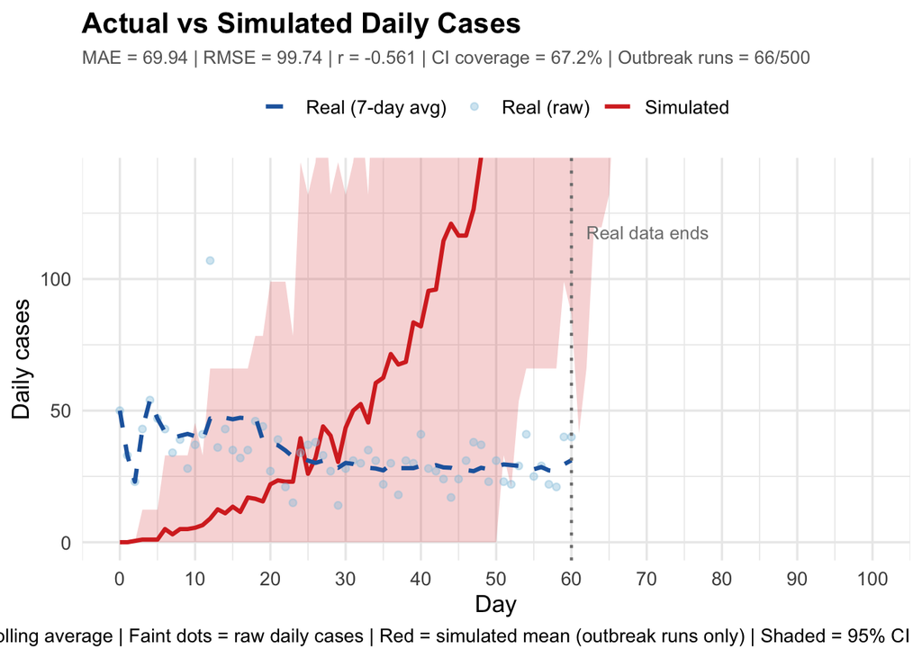

```r
# use only outbreak runs for comparison
outbreak_runs <- run_outcomes |>
  dplyr::filter(outcome == "Major outbreak") |>
  dplyr::pull(sim_num)

simulated_daily_outbreaks <- sim_hist |>
  dplyr::filter(
    state == "Recovered",
    sim_num %in% outbreak_runs
  ) |>
  dplyr::arrange(sim_num, date) |>
  dplyr::group_by(sim_num) |>
  dplyr::mutate(new_cases = counts - lag(counts, default = 0)) |>
  dplyr::ungroup() |>
  dplyr::group_by(date) |>
  dplyr::summarise(
    mean = mean(new_cases),
    lo95 = quantile(new_cases, 0.025),
    hi95 = quantile(new_cases, 0.975),
    .groups = "drop"
  )

# scale simulation UP to Utah population
scale_up <- 3300000 / 100000

simulated_plot <- simulated_daily_outbreaks |>
  mutate(
    mean = mean * scale_up,
    lo95 = lo95 * scale_up,
    hi95 = hi95 * scale_up
  )

# real data
real_raw <- covid_data |>
  mutate(date = as.numeric(Date - min(Date))) |>
  select(date, scaled_cases = Daily.Cases)

real_smooth <- covid_data |>
  mutate(date = as.numeric(Date - min(Date))) |>
  select(date, scaled_cases = roll7_filled)
comparison <- real_smooth |>
  dplyr::inner_join(simulated_plot, by = "date") |>
  dplyr::mutate(
    residual      = scaled_cases - mean,
    abs_error     = abs(residual),
    squared_error = residual ^ 2,
    pct_error     = abs(residual) / (scaled_cases + 1) * 100,
    inside_ci     = scaled_cases >= lo95 & scaled_cases <= hi95
  )

mae         <- mean(comparison$abs_error)
rmse        <- sqrt(mean(comparison$squared_error))
mape        <- mean(comparison$pct_error)
corr        <- cor(comparison$scaled_cases, comparison$mean)
ci_coverage <- mean(comparison$inside_ci) * 100

# plot
ggplot() +
  geom_ribbon(
    data = simulated_plot,
    aes(x = date, ymin = lo95, ymax = hi95),
    fill = "#d73027", alpha = 0.2
  ) +
  geom_line(
    data = simulated_plot,
    aes(x = date, y = mean, colour = "Simulated"),
    linewidth = 1.1
  ) +
  geom_point(
    data = real_raw,
    aes(x = date, y = scaled_cases, colour = "Real (raw)"),
    size = 1.5, alpha = 0.4
  ) +
  geom_line(
    data = real_smooth,
    aes(x = date, y = scaled_cases, colour = "Real (7-day avg)"),
    linewidth = 1.1, linetype = "dashed"
  ) +
  geom_vline(
    xintercept = 60,
    linetype   = "dotted",
    colour     = "grey50",
    linewidth  = 0.8
  ) +
  annotate(
    "text",
    x      = 62,
    y      = max(real_raw$scaled_cases) * 1.1,
    label  = "Real data ends",
    colour = "grey50",
    size   = 3.5,
    hjust  = 0
  ) +
  scale_x_continuous(
    breaks = seq(0, 100, by = 10),
    limits = c(0, 100)
  ) +
  scale_y_continuous(labels = scales::comma) +
  coord_cartesian(ylim = c(0, max(real_raw$scaled_cases) * 1.3)) +  # fix: only one coord_cartesian
  scale_colour_manual(
    values = c(
      "Simulated"        = "#d73027",
      "Real (raw)"       = "#92c5de",
      "Real (7-day avg)" = "#2166ac"
    ),
    name = NULL
  ) +
  labs(
    title    = "Actual vs Simulated Daily Cases",
    subtitle = sprintf(
      "MAE = %.2f | RMSE = %.2f | r = %.3f | CI coverage = %.1f%% | Outbreak runs = %d/500",
      mae, rmse, corr, ci_coverage, length(outbreak_runs)
    ),
    x       = "Day",
    y       = "Daily cases",
    caption = paste(
      "Solid blue = 7-day rolling average | Faint dots = raw daily cases",
      "| Red = simulated mean (outbreak runs only)",
      "| Shaded = 95% CI"
    )
  ) +
  theme_minimal(base_size = 13) +
  theme(
    legend.position = "top",
    plot.title      = element_text(face = "bold"),
    plot.subtitle   = element_text(colour = "grey40", size = 10)
  )
```

Next, I compare actual outbreak with simulated one.

```r
# final epidemic size
final_sizes <- sim_hist |>
  dplyr::filter(state == "Recovered", date == max(date)) |>
  dplyr::pull(counts)

cat(
  "\n TOTAL PEOPLE INFECTED \n",
  sprintf("Mean final size:        %s agents\n",    format(round(mean(final_sizes)), big.mark = ",")),
  sprintf("Median final size:      %s agents\n",    format(round(median(final_sizes)), big.mark = ",")),
  sprintf("95%% CI lower:           %s agents\n",   format(round(quantile(final_sizes, 0.025)), big.mark = ",")),
  sprintf("95%% CI upper:           %s agents\n",   format(round(quantile(final_sizes, 0.975)), big.mark = ",")),
  sprintf("Max (worst case):       %s agents\n",    format(max(final_sizes), big.mark = ",")),
  sprintf("Min (best case):        %s agents\n",    format(min(final_sizes), big.mark = ",")),
  sprintf("Attack rate (mean):     %.1f%%\n",        mean(final_sizes) / N_agents * 100),
  sprintf("P(extinction):          %.1f%%\n",        mean(final_sizes < 1000) * 100),
  sprintf("P(major outbreak):      %.1f%%\n",        mean(final_sizes >= 1000) * 100),
  "\nScaled to Salt Lake County (1.2M):\n",
  sprintf("  Mean infections:      %s people\n",    format(round(mean(final_sizes) * 12), big.mark = ",")),
  sprintf("  95%% CI:              [%s, %s] people\n",
          format(round(quantile(final_sizes, 0.025) * 12), big.mark = ","),
          format(round(quantile(final_sizes, 0.975) * 12), big.mark = ","))
)
```

```
 TOTAL PEOPLE INFECTED
 Mean final size:        359 agents
 Median final size:      4 agents
 95% CI lower:           1 agents
 95% CI upper:           2,353 agents
 Max (worst case):       3,462 agents
 Min (best case):        1 agents
 Attack rate (mean):     0.4%
 P(extinction):          86.8%
 P(major outbreak):      13.2%

Scaled to Salt Lake County (1.2M):
   Mean infections:      4,305 people
   95% CI:              [12, 28,237] people
```

```r
cat(
  "\n REAL DATA SUMMARY \n",
  sprintf("Period:              %s to %s\n",
          as.character(min(covid_data$Date)),
          as.character(max(covid_data$Date))),
  sprintf("Days:                %d\n", nrow(covid_data)),
  sprintf("Total cases:         %s\n", format(sum(covid_data$Daily.Cases), big.mark = ",")),
  sprintf("Mean daily cases:    %.1f\n", mean(covid_data$Daily.Cases)),
  sprintf("Median daily cases:  %.1f\n", median(covid_data$Daily.Cases)),
  sprintf("Max daily cases:     %s\n", format(max(covid_data$Daily.Cases), big.mark = ",")),
  sprintf("Min daily cases:     %s\n", format(min(covid_data$Daily.Cases), big.mark = ",")),
  "\nScaled to Salt Lake County (36%% of Utah):\n",
  sprintf("  Total SLC cases:   %s\n",
          format(round(sum(covid_data$Daily.Cases) * 0.364), big.mark = ",")),
  sprintf("  Mean daily SLC:    %.1f\n",
          mean(covid_data$Daily.Cases) * 0.364)
)
```

```
 REAL DATA SUMMARY
 Period:              2025-03-07 to 2025-05-06
 Days:                61
 Total cases:         2,034
 Mean daily cases:    33.3
 Median daily cases:  31.0
 Max daily cases:     107
 Min daily cases:     14

Scaled to Salt Lake County (36%% of Utah):
   Total SLC cases:   740
   Mean daily SLC:    12.1
```

## Adding immunity

Cause the graph has increasing outbreak, I just wanted to try with 20% people with prior immunity through vaccination.

Since 20% of poplulation is vaccinated, effective

R0 = R0 ( 1-p ) => 1.75 * 0.8 = 1.4

Hence, after k days, effective infected people will be reduced by N * (0.8)^(k/7).

So, I am keeping best_rate as it is, 0.25. Incubation days means day from being infected to the day infection starts spreading. How long an agent stays in the Exposedstate before becoming infectious.

```r
prior_immunity <- 0.20   # 20% already immune at start


entities_immune <- lapply(seq_along(dnames), function(i) {
  entity(dnames[i], entity_sizes[i], as_proportion = FALSE)
})

covid_model_immune <- ModelSEIRMixing(
  name              = "COVID-19 SLC + Prior Immunity",
  n                 = N_agents,
  prevalence        = 1 / N_agents,        # single seed
  transmission_rate = best_rate,            # same rate from sweep
  recovery_rate     = 1 / 7,
  incubation_days   = 4,
  contact_matrix    = mm_stochastic
)

for (e in entities_immune) add_entity(covid_model_immune, e)


prior_immunity_tool <- tool(
  name                     = "Prior Immunity",
  susceptibility_reduction = 1.0,   # fully immune
  transmission_reduction   = 0.0,
  recovery_enhancer        = 0.0,
  death_reduction          = 0.0,
  prevalence               = prior_immunity,   # 40% of agents
  as_proportion            = TRUE
)

add_tool(covid_model_immune, prior_immunity_tool)

print(covid_model_immune)
```

```
________________________________________________________________________________
Susceptible-Exposed-Infected-Removed (SEIR) with Mixing
It features 100000 agents, 1 virus(es), and 1 tool(s).
The model has 4 states. The model hasn't been run yet.
```

```r
saver_immune <- make_saver("total_hist")

run_multiple(
  covid_model_immune,
  ndays    = 100,
  nsims    = 500,
  saver    = saver_immune,
  nthreads = parallel::detectCores(logical = FALSE)
)
```

```
Starting multiple runs (500)
_________________________________________________________________________
_________________________________________________________________________
||||||||||||||||||||||||||||||||||||||||||||||||||||||||||||||||||||||||| done.
```

```r
sim_hist_immune <- run_multiple_get_results(covid_model_immune)$total_hist

# quick check
cat(
  "IMMUNITY MODEL \n",
  "Max infected:", max(sim_hist_immune$counts[sim_hist_immune$state == "Infected"]), "\n",
  "Max recovered:", max(sim_hist_immune$counts[sim_hist_immune$state == "Recovered"]), "\n"
)
```

```
IMMUNITY MODEL
 Max infected: 232
 Max recovered: 1065
```

As shown, the above results show that the outbreak only infected few people out of 100k. with ( 20% immunity )

```r
get_summary <- function(sh, model_name) {
  sh |>
    dplyr::filter(state == "Recovered") |>
    dplyr::arrange(sim_num, date) |>
    dplyr::group_by(sim_num) |>
    dplyr::mutate(new_cases = counts - lag(counts, default = 0)) |>
    dplyr::ungroup() |>
    dplyr::group_by(date) |>
    dplyr::summarise(
      mean = mean(new_cases),
      lo95 = quantile(new_cases, 0.025),
      hi95 = quantile(new_cases, 0.975),
      .groups = "drop"
    ) |>
    mutate(model = model_name)
}

baseline_summary <- get_summary(sim_hist,        "Baseline (no immunity)")
immune_summary   <- get_summary(sim_hist_immune,  "40% Prior immunity")

# scale up
scale_up <- 3300000 / 100000

baseline_plot <- baseline_summary |>
  mutate(mean = mean * scale_up, lo95 = lo95 * scale_up, hi95 = hi95 * scale_up)

immune_plot <- immune_summary |>
  mutate(mean = mean * scale_up, lo95 = lo95 * scale_up, hi95 = hi95 * scale_up)

all_models <- bind_rows(baseline_plot, immune_plot)
```

[figure not shown]

```r
real_smooth <- covid_data |>
  mutate(date = as.numeric(Date - min(Date))) |>
  select(date, scaled_cases = roll7_filled)

real_raw <- covid_data |>
  mutate(date = as.numeric(Date - min(Date))) |>
  select(date, scaled_cases = Daily.Cases)

ggplot() +
  # baseline CI
  geom_ribbon(
    data = baseline_plot,
    aes(x = date, ymin = lo95, ymax = hi95),
    fill = "#d73027", alpha = 0.15
  ) +
  # immune CI
  geom_ribbon(
    data = immune_plot,
    aes(x = date, ymin = lo95, ymax = hi95),
    fill = "#4393c3", alpha = 0.15
  ) +
  # baseline mean
  geom_line(
    data = baseline_plot,
    aes(x = date, y = mean, colour = "Baseline (no immunity)"),
    linewidth = 1.1
  ) +
  # immune mean
  geom_line(
    data = immune_plot,
    aes(x = date, y = mean, colour = "40% Prior immunity"),
    linewidth = 1.1
  ) +
  # real raw dots
  geom_point(
    data = real_raw,
    aes(x = date, y = scaled_cases, colour = "Real (raw)"),
    size = 1.5, alpha = 0.4
  ) +
  # real smooth line
  geom_line(
    data = real_smooth,
    aes(x = date, y = scaled_cases, colour = "Real (7-day avg)"),
    linewidth = 1.1, linetype = "dashed"
  ) +
  geom_vline(
    xintercept = 60,
    linetype   = "dotted",
    colour     = "grey50",
    linewidth  = 0.8
  ) +
  annotate(
    "text",
    x = 62, y = max(real_raw$scaled_cases) * 1.1,
    label = "Real data ends",
    colour = "grey50", size = 3.5, hjust = 0
  ) +
  scale_x_continuous(breaks = seq(0, 100, by = 10), limits = c(0, 100)) +
  scale_y_continuous(labels = scales::comma) +
  coord_cartesian(ylim = c(0, max(real_raw$scaled_cases) * 1.5)) +
  scale_colour_manual(
    values = c(
      "Baseline (no immunity)" = "#d73027",
      "40% Prior immunity"     = "#228B22",
      "Real (raw)"             = "#92c5de",
      "Real (7-day avg)"       = "#2166ac"
    ),
    name = NULL
  ) +
  labs(
    title    = "Baseline vs Prior Immunity Model — Daily Cases",
    subtitle = "Salt Lake County | 100K agents | 500 replicates | Single seed",
    x        = "Day",
    y        = "Daily cases",
    caption  = paste(
      "Red = baseline (0% immunity) | Blue = 40% prior immunity",
      "| Dashed = real 7-day avg | Shaded = 95% CI",
      "| Simulation scaled up ×33 to Utah population"
    )
  ) +
  theme_minimal(base_size = 13) +
  theme(
    legend.position = "top",
    plot.title      = element_text(face = "bold"),
    plot.subtitle   = element_text(colour = "grey40", size = 10)
  )
```

## Final Comparision

```r
# accuracy for baseline model
comparison_baseline <- real_smooth |>
  dplyr::inner_join(simulated_plot, by = "date") |>
  dplyr::mutate(
    abs_error     = abs(scaled_cases - mean),
    squared_error = (scaled_cases - mean)^2,
    pct_error     = abs(scaled_cases - mean) / (scaled_cases + 1) * 100,
    inside_ci     = scaled_cases >= lo95 & scaled_cases <= hi95
  )

# accuracy for immunity model
# scale up immune model
simulated_plot_immune <- immune_summary |>
  mutate(
    mean = mean * scale_up,
    lo95 = lo95 * scale_up,
    hi95 = hi95 * scale_up
  )

comparison_immune <- real_smooth |>
  dplyr::inner_join(simulated_plot_immune, by = "date") |>
  dplyr::mutate(
    abs_error     = abs(scaled_cases - mean),
    squared_error = (scaled_cases - mean)^2,
    pct_error     = abs(scaled_cases - mean) / (scaled_cases + 1) * 100,
    inside_ci     = scaled_cases >= lo95 & scaled_cases <= hi95
  )

# compute metrics for both
get_metrics <- function(comp, model_name) {
  data.frame(
    Model       = model_name,
    MAE         = round(mean(comp$abs_error), 2),
    RMSE        = round(sqrt(mean(comp$squared_error)), 2),
    MAPE        = round(mean(comp$pct_error), 1),
    Correlation = round(cor(comp$scaled_cases, comp$mean), 3),
    CI_Coverage = round(mean(comp$inside_ci) * 100, 1)
  )
}

metrics_both <- rbind(
  get_metrics(comparison_baseline, "Baseline (no immunity)"),
  get_metrics(comparison_immune,   "20% Prior immunity")
)

# print to console
cat(
  "\n FINAL MODEL ACCURACY COMPARISON \n",
  "\nBaseline (no immunity):\n",
  sprintf("  MAE  (Mean Absolute Error):       %.2f\n", metrics_both$MAE[1]),
  sprintf("  RMSE (Root Mean Squared Error):   %.2f\n", metrics_both$RMSE[1]),
  sprintf("  MAPE (Mean Abs Pct Error):        %.1f%%\n", metrics_both$MAPE[1]),
  sprintf("  Correlation (r):                  %.3f\n", metrics_both$Correlation[1]),
  sprintf("  CI Coverage (real inside 95%% CI): %.1f%%\n", metrics_both$CI_Coverage[1]),
  "\n20%% Prior immunity:\n",
  sprintf("  MAE  (Mean Absolute Error):       %.2f\n", metrics_both$MAE[2]),
  sprintf("  RMSE (Root Mean Squared Error):   %.2f\n", metrics_both$RMSE[2]),
  sprintf("  MAPE (Mean Abs Pct Error):        %.1f%%\n", metrics_both$MAPE[2]),
  sprintf("  Correlation (r):                  %.3f\n", metrics_both$Correlation[2]),
  sprintf("  CI Coverage (real inside 95%% CI): %.1f%%\n", metrics_both$CI_Coverage[2])
)
```

```
 FINAL MODEL ACCURACY COMPARISON

Baseline (no immunity):
   MAE  (Mean Absolute Error):       69.94
   RMSE (Root Mean Squared Error):   99.74
   MAPE (Mean Abs Pct Error):        222.9%
   Correlation (r):                  -0.561
   CI Coverage (real inside 95% CI): 67.2%

20%% Prior immunity:
   MAE  (Mean Absolute Error):       26.70
   RMSE (Root Mean Squared Error):   28.83
   MAPE (Mean Abs Pct Error):        74.0%
   Correlation (r):                  -0.625
   CI Coverage (real inside 95% CI): 65.6%
```